# Risk Factor Analysis

## Outcome Variable

**Outcome Variable:** swasted

## Predictor Variables

**Intervention Variable:** gagebrth

**Adjustment Set:**

- arm
- sex
- W_mage
- meducyrs
- feducyrs
- hhwealth_quart
- brthmon
- W_parity
- impsan
- delta_W_mage
- delta_meducyrs
- delta_feducyrs
- delta_hhwealth_quart
- delta_brthmon
- delta_W_parity
- delta_impsan

## Stratifying Variables

The analysis was stratified on these variable(s):

- agecat
- studyid
- country

## Data Summary

| agecat | studyid | country | gagebrth | swasted | n_cell | n |
| --- | --- | --- | --- | --- | --- | --- |
| Birth | ki1000108-CMC-V-BCS-2002 | INDIA | Full or late term | 0 | 52 | 86 |
| Birth | ki1000108-CMC-V-BCS-2002 | INDIA | Full or late term | 1 | 1 | 86 |
| Birth | ki1000108-CMC-V-BCS-2002 | INDIA | Preterm | 0 | 11 | 86 |
| Birth | ki1000108-CMC-V-BCS-2002 | INDIA | Preterm | 1 | 0 | 86 |
| Birth | ki1000108-CMC-V-BCS-2002 | INDIA | Early term | 0 | 22 | 86 |
| Birth | ki1000108-CMC-V-BCS-2002 | INDIA | Early term | 1 | 0 | 86 |
| Birth | ki1000108-IRC | INDIA | Full or late term | 0 | 187 | 328 |
| Birth | ki1000108-IRC | INDIA | Full or late term | 1 | 26 | 328 |
| Birth | ki1000108-IRC | INDIA | Preterm | 0 | 22 | 328 |
| Birth | ki1000108-IRC | INDIA | Preterm | 1 | 10 | 328 |
| Birth | ki1000108-IRC | INDIA | Early term | 0 | 67 | 328 |
| Birth | ki1000108-IRC | INDIA | Early term | 1 | 16 | 328 |
| Birth | ki1000109-EE | PAKISTAN | Full or late term | 0 | 8 | 177 |
| Birth | ki1000109-EE | PAKISTAN | Full or late term | 1 | 1 | 177 |
| Birth | ki1000109-EE | PAKISTAN | Preterm | 0 | 129 | 177 |
| Birth | ki1000109-EE | PAKISTAN | Preterm | 1 | 3 | 177 |
| Birth | ki1000109-EE | PAKISTAN | Early term | 0 | 34 | 177 |
| Birth | ki1000109-EE | PAKISTAN | Early term | 1 | 2 | 177 |
| Birth | ki1017093c-NIH-Crypto | BANGLADESH | Full or late term | 0 | 158 | 707 |
| Birth | ki1017093c-NIH-Crypto | BANGLADESH | Full or late term | 1 | 2 | 707 |
| Birth | ki1017093c-NIH-Crypto | BANGLADESH | Preterm | 0 | 218 | 707 |
| Birth | ki1017093c-NIH-Crypto | BANGLADESH | Preterm | 1 | 22 | 707 |
| Birth | ki1017093c-NIH-Crypto | BANGLADESH | Early term | 0 | 284 | 707 |
| Birth | ki1017093c-NIH-Crypto | BANGLADESH | Early term | 1 | 23 | 707 |
| Birth | ki1101329-Keneba | GAMBIA | Full or late term | 0 | 652 | 1439 |
| Birth | ki1101329-Keneba | GAMBIA | Full or late term | 1 | 57 | 1439 |
| Birth | ki1101329-Keneba | GAMBIA | Preterm | 0 | 191 | 1439 |
| Birth | ki1101329-Keneba | GAMBIA | Preterm | 1 | 15 | 1439 |
| Birth | ki1101329-Keneba | GAMBIA | Early term | 0 | 496 | 1439 |
| Birth | ki1101329-Keneba | GAMBIA | Early term | 1 | 28 | 1439 |

[output cut: 162 more lines]

The following strata were considered:

- agecat: 24 months, studyid: ki1000108-CMC-V-BCS-2002, country: INDIA
- agecat: 24 months, studyid: ki1000108-IRC, country: INDIA
- agecat: 24 months, studyid: ki1000109-EE, country: PAKISTAN
- agecat: 24 months, studyid: ki1017093c-NIH-Crypto, country: BANGLADESH
- agecat: 24 months, studyid: ki1066203-TanzaniaChild2, country: TANZANIA, UNITED REPUBLIC OF
- agecat: 24 months, studyid: ki1101329-Keneba, country: GAMBIA
- agecat: 24 months, studyid: ki1119695-PROBIT, country: BELARUS
- agecat: 24 months, studyid: ki1135781-COHORTS, country: GUATEMALA
- agecat: 24 months, studyid: ki1135781-COHORTS, country: INDIA
- agecat: 24 months, studyid: ki1135781-COHORTS, country: PHILIPPINES
- agecat: 24 months, studyid: kiGH5241-JiVitA-3, country: BANGLADESH
- agecat: 6 months, studyid: ki1000108-CMC-V-BCS-2002, country: INDIA
- agecat: 6 months, studyid: ki1000108-IRC, country: INDIA
- agecat: 6 months, studyid: ki1000109-EE, country: PAKISTAN
- agecat: 6 months, studyid: ki1017093c-NIH-Crypto, country: BANGLADESH
- agecat: 6 months, studyid: ki1066203-TanzaniaChild2, country: TANZANIA, UNITED REPUBLIC OF
- agecat: 6 months, studyid: ki1101329-Keneba, country: GAMBIA
- agecat: 6 months, studyid: ki1119695-PROBIT, country: BELARUS
- agecat: 6 months, studyid: ki1135781-COHORTS, country: GUATEMALA
- agecat: 6 months, studyid: ki1135781-COHORTS, country: INDIA
- agecat: 6 months, studyid: ki1135781-COHORTS, country: PHILIPPINES
- agecat: 6 months, studyid: kiGH5241-JiVitA-3, country: BANGLADESH
- agecat: Birth, studyid: ki1000108-CMC-V-BCS-2002, country: INDIA
- agecat: Birth, studyid: ki1000108-IRC, country: INDIA
- agecat: Birth, studyid: ki1000109-EE, country: PAKISTAN
- agecat: Birth, studyid: ki1017093c-NIH-Crypto, country: BANGLADESH
- agecat: Birth, studyid: ki1101329-Keneba, country: GAMBIA
- agecat: Birth, studyid: ki1119695-PROBIT, country: BELARUS
- agecat: Birth, studyid: ki1135781-COHORTS, country: GUATEMALA
- agecat: Birth, studyid: ki1135781-COHORTS, country: INDIA
- agecat: Birth, studyid: ki1135781-COHORTS, country: PHILIPPINES
- agecat: Birth, studyid: kiGH5241-JiVitA-3, country: BANGLADESH

### Dropped Strata

Some strata were dropped due to rare outcomes:

- agecat: Birth, studyid: ki1000108-CMC-V-BCS-2002, country: INDIA
- agecat: Birth, studyid: ki1000109-EE, country: PAKISTAN
- agecat: Birth, studyid: ki1017093c-NIH-Crypto, country: BANGLADESH
- agecat: 6 months, studyid: ki1000108-CMC-V-BCS-2002, country: INDIA
- agecat: 6 months, studyid: ki1000109-EE, country: PAKISTAN
- agecat: 6 months, studyid: ki1017093c-NIH-Crypto, country: BANGLADESH
- agecat: 6 months, studyid: ki1066203-TanzaniaChild2, country: TANZANIA, UNITED REPUBLIC OF
- agecat: 6 months, studyid: ki1101329-Keneba, country: GAMBIA
- agecat: 6 months, studyid: ki1119695-PROBIT, country: BELARUS
- agecat: 6 months, studyid: ki1135781-COHORTS, country: GUATEMALA
- agecat: 24 months, studyid: ki1000108-CMC-V-BCS-2002, country: INDIA
- agecat: 24 months, studyid: ki1000108-IRC, country: INDIA
- agecat: 24 months, studyid: ki1000109-EE, country: PAKISTAN
- agecat: 24 months, studyid: ki1017093c-NIH-Crypto, country: BANGLADESH
- agecat: 24 months, studyid: ki1066203-TanzaniaChild2, country: TANZANIA, UNITED REPUBLIC OF
- agecat: 24 months, studyid: ki1101329-Keneba, country: GAMBIA
- agecat: 24 months, studyid: ki1119695-PROBIT, country: BELARUS
- agecat: 24 months, studyid: ki1135781-COHORTS, country: GUATEMALA
- agecat: 24 months, studyid: ki1135781-COHORTS, country: INDIA

## Methods Detail

We’re interested in the causal parameters $E[Y_a]$ for all values of $a \in \mathcal{A}$. These parameters represent the mean outcome if, possibly contrary to fact, we intervened to set all units to have $A=a$. Under the randomization and positivity assumptions, these are identified by the statistical parameters $\psi_a=E_W[E_{Y|A,W}(Y|A=a,W)]$. In addition, we’re interested in the mean of $Y$, $E[Y]$ under no intervention (the observed mean). We will estimate these parameters by using SuperLearner to fit the relevant likelihood factors – $E_{Y|A,W}(Y|A=a,W)$ and $p(A=a|W)$, and then updating our likelihood fit using a joint TMLE.

For unadjusted analyses ($W=\{\}$), initial likelihoods were estimated using Lrnr_glm to estimate the simple $E(Y|A)$ and Lrnr_mean to estimate $p(A)$. For adjusted analyses, a small library containing Lrnr_glmnet, Lrnr_xgboost, and Lrnr_mean was used.

Having estimated these parameters, we will then use the delta method to estimate relative risks and attributable risks relative to a prespecified baseline level of $A$.

# Results Detail

## Results Plots

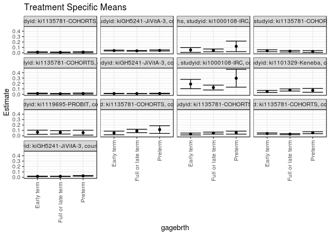

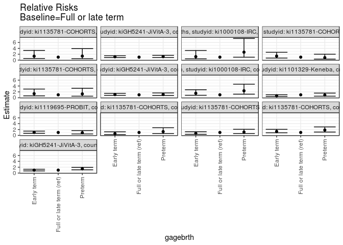

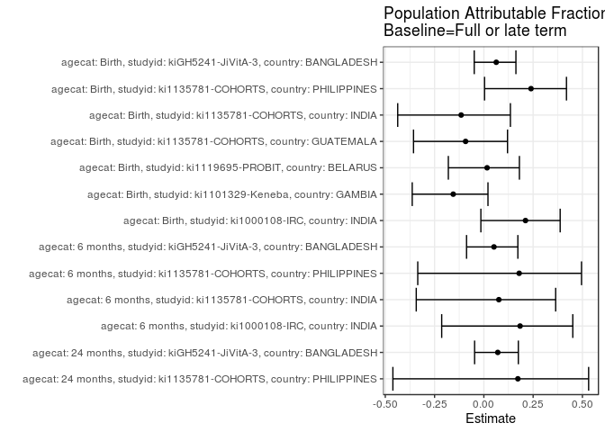

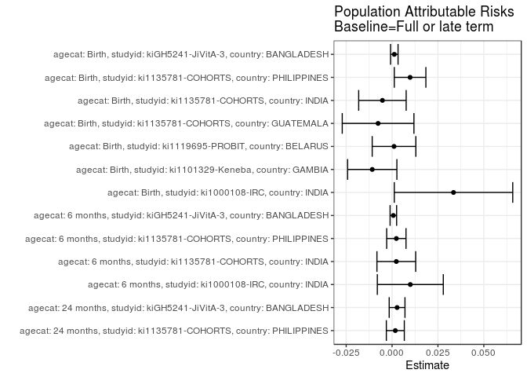

## Results Table

### Parameter: TSM

| agecat | studyid | country | intervention_level | baseline_level | estimate | ci_lower | ci_upper |
| --- | --- | --- | --- | --- | --- | --- | --- |
| Birth | ki1000108-IRC | INDIA | Full or late term | NA | 0.1250492 | 0.0796707 | 0.1704276 |
| Birth | ki1000108-IRC | INDIA | Preterm | NA | 0.2970281 | 0.1316979 | 0.4623584 |
| Birth | ki1000108-IRC | INDIA | Early term | NA | 0.1898578 | 0.1034767 | 0.2762388 |
| Birth | ki1101329-Keneba | GAMBIA | Full or late term | NA | 0.0802910 | 0.0602273 | 0.1003547 |
| Birth | ki1101329-Keneba | GAMBIA | Preterm | NA | 0.0733514 | 0.0375461 | 0.1091566 |
| Birth | ki1101329-Keneba | GAMBIA | Early term | NA | 0.0531588 | 0.0339396 | 0.0723779 |
| Birth | ki1119695-PROBIT | BELARUS | Full or late term | NA | 0.0644328 | 0.0329129 | 0.0959527 |
| Birth | ki1119695-PROBIT | BELARUS | Preterm | NA | 0.0581638 | 0.0132407 | 0.1030869 |
| Birth | ki1119695-PROBIT | BELARUS | Early term | NA | 0.0658159 | 0.0267064 | 0.1049254 |
| Birth | ki1135781-COHORTS | GUATEMALA | Full or late term | NA | 0.0897833 | 0.0585802 | 0.1209863 |
| Birth | ki1135781-COHORTS | GUATEMALA | Preterm | NA | 0.1153846 | 0.0444216 | 0.1863476 |
| Birth | ki1135781-COHORTS | GUATEMALA | Early term | NA | 0.0526316 | 0.0191341 | 0.0861291 |
| Birth | ki1135781-COHORTS | INDIA | Full or late term | NA | 0.0508110 | 0.0326589 | 0.0689630 |
| Birth | ki1135781-COHORTS | INDIA | Preterm | NA | 0.0583687 | 0.0306541 | 0.0860832 |
| Birth | ki1135781-COHORTS | INDIA | Early term | NA | 0.0340397 | 0.0169096 | 0.0511698 |
| Birth | ki1135781-COHORTS | PHILIPPINES | Full or late term | NA | 0.0312361 | 0.0211586 | 0.0413137 |
| Birth | ki1135781-COHORTS | PHILIPPINES | Preterm | NA | 0.0569663 | 0.0380820 | 0.0758507 |
| Birth | ki1135781-COHORTS | PHILIPPINES | Early term | NA | 0.0423602 | 0.0306694 | 0.0540510 |
| Birth | kiGH5241-JiVitA-3 | BANGLADESH | Full or late term | NA | 0.0182387 | 0.0150064 | 0.0214711 |
| Birth | kiGH5241-JiVitA-3 | BANGLADESH | Preterm | NA | 0.0268633 | 0.0212028 | 0.0325238 |
| Birth | kiGH5241-JiVitA-3 | BANGLADESH | Early term | NA | 0.0179148 | 0.0135796 | 0.0222500 |
| 6 months | ki1000108-IRC | INDIA | Full or late term | NA | 0.0441767 | 0.0186206 | 0.0697328 |
| 6 months | ki1000108-IRC | INDIA | Preterm | NA | 0.1190476 | 0.0209812 | 0.2171141 |
| 6 months | ki1000108-IRC | INDIA | Early term | NA | 0.0515464 | 0.0074879 | 0.0956049 |
| 6 months | ki1135781-COHORTS | INDIA | Full or late term | NA | 0.0281690 | 0.0145571 | 0.0417810 |
| 6 months | ki1135781-COHORTS | INDIA | Preterm | NA | 0.0234114 | 0.0062660 | 0.0405568 |
| 6 months | ki1135781-COHORTS | INDIA | Early term | NA | 0.0382022 | 0.0203858 | 0.0560186 |
| 6 months | ki1135781-COHORTS | PHILIPPINES | Full or late term | NA | 0.0107004 | 0.0044097 | 0.0169910 |
| 6 months | ki1135781-COHORTS | PHILIPPINES | Preterm | NA | 0.0139860 | 0.0043606 | 0.0236114 |
| 6 months | ki1135781-COHORTS | PHILIPPINES | Early term | NA | 0.0147465 | 0.0075730 | 0.0219201 |
| 6 months | kiGH5241-JiVitA-3 | BANGLADESH | Full or late term | NA | 0.0129945 | 0.0102661 | 0.0157229 |
| 6 months | kiGH5241-JiVitA-3 | BANGLADESH | Preterm | NA | 0.0144644 | 0.0095061 | 0.0194227 |
| 6 months | kiGH5241-JiVitA-3 | BANGLADESH | Early term | NA | 0.0141650 | 0.0105144 | 0.0178156 |
| 24 months | ki1135781-COHORTS | PHILIPPINES | Full or late term | NA | 0.0085197 | 0.0026400 | 0.0143995 |
| 24 months | ki1135781-COHORTS | PHILIPPINES | Preterm | NA | 0.0116054 | 0.0023715 | 0.0208394 |
| 24 months | ki1135781-COHORTS | PHILIPPINES | Early term | NA | 0.0113169 | 0.0046657 | 0.0179680 |
| 24 months | kiGH5241-JiVitA-3 | BANGLADESH | Full or late term | NA | 0.0360463 | 0.0299732 | 0.0421194 |
| 24 months | kiGH5241-JiVitA-3 | BANGLADESH | Preterm | NA | 0.0429223 | 0.0322067 | 0.0536380 |
| 24 months | kiGH5241-JiVitA-3 | BANGLADESH | Early term | NA | 0.0408740 | 0.0326056 | 0.0491423 |

### Parameter: E(Y)

| agecat | studyid | country | intervention_level | baseline_level | estimate | ci_lower | ci_upper |
| --- | --- | --- | --- | --- | --- | --- | --- |
| Birth | ki1000108-IRC | INDIA | NA | NA | 0.1585366 | 0.1189492 | 0.1981239 |
| Birth | ki1101329-Keneba | GAMBIA | NA | NA | 0.0694927 | 0.0563496 | 0.0826358 |
| Birth | ki1119695-PROBIT | BELARUS | NA | NA | 0.0655098 | 0.0324802 | 0.0985393 |
| Birth | ki1135781-COHORTS | GUATEMALA | NA | NA | 0.0821678 | 0.0596429 | 0.1046927 |
| Birth | ki1135781-COHORTS | INDIA | NA | NA | 0.0455655 | 0.0339017 | 0.0572293 |
| Birth | ki1135781-COHORTS | PHILIPPINES | NA | NA | 0.0410578 | 0.0338021 | 0.0483134 |
| Birth | kiGH5241-JiVitA-3 | BANGLADESH | NA | NA | 0.0194627 | 0.0170189 | 0.0219065 |
| 6 months | ki1000108-IRC | INDIA | NA | NA | 0.0541237 | 0.0315811 | 0.0766663 |
| 6 months | ki1135781-COHORTS | INDIA | NA | NA | 0.0304878 | 0.0211813 | 0.0397943 |
| 6 months | ki1135781-COHORTS | PHILIPPINES | NA | NA | 0.0130354 | 0.0087443 | 0.0173265 |
| 6 months | kiGH5241-JiVitA-3 | BANGLADESH | NA | NA | 0.0136969 | 0.0115537 | 0.0158401 |
| 24 months | ki1135781-COHORTS | PHILIPPINES | NA | NA | 0.0102965 | 0.0062804 | 0.0143127 |
| 24 months | kiGH5241-JiVitA-3 | BANGLADESH | NA | NA | 0.0387862 | 0.0342718 | 0.0433007 |

### Parameter: RR

| agecat | studyid | country | intervention_level | baseline_level | estimate | ci_lower | ci_upper |
| --- | --- | --- | --- | --- | --- | --- | --- |
| Birth | ki1000108-IRC | INDIA | Full or late term | Full or late term | 1.0000000 | 1.0000000 | 1.000000 |
| Birth | ki1000108-IRC | INDIA | Preterm | Full or late term | 2.3752911 | 1.2215035 | 4.618904 |
| Birth | ki1000108-IRC | INDIA | Early term | Full or late term | 1.5182652 | 0.8482280 | 2.717582 |
| Birth | ki1101329-Keneba | GAMBIA | Full or late term | Full or late term | 1.0000000 | 1.0000000 | 1.000000 |
| Birth | ki1101329-Keneba | GAMBIA | Preterm | Full or late term | 0.9135688 | 0.5279234 | 1.580926 |
| Birth | ki1101329-Keneba | GAMBIA | Early term | Full or late term | 0.6620764 | 0.4265823 | 1.027575 |
| Birth | ki1119695-PROBIT | BELARUS | Full or late term | Full or late term | 1.0000000 | 1.0000000 | 1.000000 |
| Birth | ki1119695-PROBIT | BELARUS | Preterm | Full or late term | 0.9027045 | 0.4956641 | 1.644007 |
| Birth | ki1119695-PROBIT | BELARUS | Early term | Full or late term | 1.0214659 | 0.7105008 | 1.468531 |
| Birth | ki1135781-COHORTS | GUATEMALA | Full or late term | Full or late term | 1.0000000 | 1.0000000 | 1.000000 |
| Birth | ki1135781-COHORTS | GUATEMALA | Preterm | Full or late term | 1.2851459 | 0.6341034 | 2.604622 |
| Birth | ki1135781-COHORTS | GUATEMALA | Early term | Full or late term | 0.5862069 | 0.2838695 | 1.210551 |
| Birth | ki1135781-COHORTS | INDIA | Full or late term | Full or late term | 1.0000000 | 1.0000000 | 1.000000 |
| Birth | ki1135781-COHORTS | INDIA | Preterm | Full or late term | 1.1487415 | 0.6340629 | 2.081193 |
| Birth | ki1135781-COHORTS | INDIA | Early term | Full or late term | 0.6699289 | 0.3611839 | 1.242593 |
| Birth | ki1135781-COHORTS | PHILIPPINES | Full or late term | Full or late term | 1.0000000 | 1.0000000 | 1.000000 |
| Birth | ki1135781-COHORTS | PHILIPPINES | Preterm | Full or late term | 1.8237309 | 1.1485770 | 2.895752 |
| Birth | ki1135781-COHORTS | PHILIPPINES | Early term | Full or late term | 1.3561272 | 0.8870828 | 2.073178 |
| Birth | kiGH5241-JiVitA-3 | BANGLADESH | Full or late term | Full or late term | 1.0000000 | 1.0000000 | 1.000000 |
| Birth | kiGH5241-JiVitA-3 | BANGLADESH | Preterm | Full or late term | 1.4728729 | 1.1130735 | 1.948977 |
| Birth | kiGH5241-JiVitA-3 | BANGLADESH | Early term | Full or late term | 0.9822412 | 0.7378708 | 1.307543 |
| 6 months | ki1000108-IRC | INDIA | Full or late term | Full or late term | 1.0000000 | 1.0000000 | 1.000000 |
| 6 months | ki1000108-IRC | INDIA | Preterm | Full or late term | 2.6948051 | 0.9848457 | 7.373718 |
| 6 months | ki1000108-IRC | INDIA | Early term | Full or late term | 1.1668228 | 0.4156900 | 3.275218 |
| 6 months | ki1135781-COHORTS | INDIA | Full or late term | Full or late term | 1.0000000 | 1.0000000 | 1.000000 |
| 6 months | ki1135781-COHORTS | INDIA | Preterm | Full or late term | 0.8311037 | 0.3456219 | 1.998523 |
| 6 months | ki1135781-COHORTS | INDIA | Early term | Full or late term | 1.3561798 | 0.6928795 | 2.654464 |
| 6 months | ki1135781-COHORTS | PHILIPPINES | Full or late term | Full or late term | 1.0000000 | 1.0000000 | 1.000000 |
| 6 months | ki1135781-COHORTS | PHILIPPINES | Preterm | Full or late term | 1.3070566 | 0.5286910 | 3.231371 |
| 6 months | ki1135781-COHORTS | PHILIPPINES | Early term | Full or late term | 1.3781315 | 0.6425394 | 2.955845 |
| 6 months | kiGH5241-JiVitA-3 | BANGLADESH | Full or late term | Full or late term | 1.0000000 | 1.0000000 | 1.000000 |
| 6 months | kiGH5241-JiVitA-3 | BANGLADESH | Preterm | Full or late term | 1.1131152 | 0.7574969 | 1.635684 |
| 6 months | kiGH5241-JiVitA-3 | BANGLADESH | Early term | Full or late term | 1.0900740 | 0.7955228 | 1.493686 |
| 24 months | ki1135781-COHORTS | PHILIPPINES | Full or late term | Full or late term | 1.0000000 | 1.0000000 | 1.000000 |
| 24 months | ki1135781-COHORTS | PHILIPPINES | Preterm | Full or late term | 1.3621857 | 0.4751277 | 3.905371 |
| 24 months | ki1135781-COHORTS | PHILIPPINES | Early term | Full or late term | 1.3283179 | 0.5365669 | 3.288366 |
| 24 months | kiGH5241-JiVitA-3 | BANGLADESH | Full or late term | Full or late term | 1.0000000 | 1.0000000 | 1.000000 |
| 24 months | kiGH5241-JiVitA-3 | BANGLADESH | Preterm | Full or late term | 1.1907546 | 0.8809901 | 1.609435 |
| 24 months | kiGH5241-JiVitA-3 | BANGLADESH | Early term | Full or late term | 1.1339293 | 0.8713814 | 1.475583 |

### Parameter: PAR

| agecat | studyid | country | intervention_level | baseline_level | estimate | ci_lower | ci_upper |
| --- | --- | --- | --- | --- | --- | --- | --- |
| Birth | ki1000108-IRC | INDIA | Full or late term | NA | 0.0334874 | 0.0012171 | 0.0657578 |
| Birth | ki1101329-Keneba | GAMBIA | Full or late term | NA | -0.0107983 | -0.0242210 | 0.0026244 |
| Birth | ki1119695-PROBIT | BELARUS | Full or late term | NA | 0.0010770 | -0.0108180 | 0.0129719 |
| Birth | ki1135781-COHORTS | GUATEMALA | Full or late term | NA | -0.0076154 | -0.0271452 | 0.0119143 |
| Birth | ki1135781-COHORTS | INDIA | Full or late term | NA | -0.0052455 | -0.0181788 | 0.0076879 |
| Birth | ki1135781-COHORTS | PHILIPPINES | Full or late term | NA | 0.0098216 | 0.0012165 | 0.0184267 |
| Birth | kiGH5241-JiVitA-3 | BANGLADESH | Full or late term | NA | 0.0012240 | -0.0008186 | 0.0032666 |
| 6 months | ki1000108-IRC | INDIA | Full or late term | NA | 0.0099470 | -0.0080254 | 0.0279194 |
| 6 months | ki1135781-COHORTS | INDIA | Full or late term | NA | 0.0023188 | -0.0082390 | 0.0128766 |
| 6 months | ki1135781-COHORTS | PHILIPPINES | Full or late term | NA | 0.0023350 | -0.0029266 | 0.0075966 |
| 6 months | kiGH5241-JiVitA-3 | BANGLADESH | Full or late term | NA | 0.0007024 | -0.0010756 | 0.0024804 |
| 24 months | ki1135781-COHORTS | PHILIPPINES | Full or late term | NA | 0.0017768 | -0.0031181 | 0.0066718 |
| 24 months | kiGH5241-JiVitA-3 | BANGLADESH | Full or late term | NA | 0.0027399 | -0.0015570 | 0.0070368 |

### Parameter: PAF

| agecat | studyid | country | intervention_level | baseline_level | estimate | ci_lower | ci_upper |
| --- | --- | --- | --- | --- | --- | --- | --- |
| Birth | ki1000108-IRC | INDIA | Full or late term | NA | 0.2112284 | -0.0151179 | 0.3871050 |
| Birth | ki1101329-Keneba | GAMBIA | Full or late term | NA | -0.1553874 | -0.3633706 | 0.0208678 |
| Birth | ki1119695-PROBIT | BELARUS | Full or late term | NA | 0.0164397 | -0.1801580 | 0.1802870 |
| Birth | ki1135781-COHORTS | GUATEMALA | Full or late term | NA | -0.0926816 | -0.3568340 | 0.1200448 |
| Birth | ki1135781-COHORTS | INDIA | Full or late term | NA | -0.1151193 | -0.4370286 | 0.1346790 |
| Birth | ki1135781-COHORTS | PHILIPPINES | Full or late term | NA | 0.2392145 | 0.0035496 | 0.4191437 |
| Birth | kiGH5241-JiVitA-3 | BANGLADESH | Full or late term | NA | 0.0628907 | -0.0487606 | 0.1626556 |
| 6 months | ki1000108-IRC | INDIA | Full or late term | NA | 0.1837827 | -0.2138954 | 0.4511795 |
| 6 months | ki1135781-COHORTS | INDIA | Full or late term | NA | 0.0760563 | -0.3429950 | 0.3643521 |
| 6 months | ki1135781-COHORTS | PHILIPPINES | Full or late term | NA | 0.1791273 | -0.3353175 | 0.4953769 |
| 6 months | kiGH5241-JiVitA-3 | BANGLADESH | Full or late term | NA | 0.0512806 | -0.0877385 | 0.1725322 |
| 24 months | ki1135781-COHORTS | PHILIPPINES | Full or late term | NA | 0.1725666 | -0.4614571 | 0.5315319 |
| 24 months | kiGH5241-JiVitA-3 | BANGLADESH | Full or late term | NA | 0.0706420 | -0.0468911 | 0.1749798 |